# Lecture 11：購買履歴から顧客の長期価値を予測する

計量経済学II

Kei Ikegami

## 前回から今回へ

- 第9回：個人の価格感応度を事後分布で表す。
- 第10回：1回の購買機会での期待増分利益を比較する。
- 第11回：その先に何回買ってくれるかを予測する。

今日の問い：購買履歴から、将来の利益をどれくらい見込めるか。

## 復習

1. クーポンの増分利益には、どの2つの利益が必要か。
2. 事後平均の係数を代入することと、確率を平均することは同じか。
3. 推定に使ったデータだけで施策ルールを評価してよいか。

Quiz 11

## 3か月買っていない顧客

- 月に1回買う人の3か月と、年に2回買う人の3か月は違う。
- ECでは、利用をやめたことが直接観測されない。
- 購買頻度の個人差と、離脱の可能性を合わせて考える。

## まず購買率の個人差

$$x_i\mid\lambda_i\sim\mathrm{Poisson}(\lambda_i T_i),\qquad
\lambda_i\sim\mathrm{Gamma}(r,\alpha).$$

$\alpha$ はrateであり、この回では価格係数ではない。

$$E[\lambda_i\mid x_i,T_i]=\frac{r+x_i}{\alpha+T_i}.$$

集団の情報と本人の履歴を合わせる。第8・9回のpartial poolingと同じ構造である。

## BG/NBD：離脱も個人で違う

- 活動中はPoisson過程で購買。
- 各購買の直後、確率 $p_i$ で離脱し、戻らない。
- $p_i\sim\mathrm{Beta}(a,b)$、$\lambda_i$ と独立。
- ここでは全員が時点0で活動中。初回購買は回数に含めない。

第1回の反復購買より前には離脱しないというモデル上の仮定がある。

## 履歴を3つの数字にまとめる

| 記号 | 内容 |
| --- | --- |
| $x_i$ | 反復購買回数 |
| $t_{x,i}$ | 最後の反復購買時点 |
| $T_i$ | 観測期間 |

このモデルでは、尤度のパラメータ依存部分はこの3つで書ける。

## 尤度は2つの経路の和

1. 観測終了まで活動している。
2. 最後の購買の直後に離脱している。

離脱を観測していないので、両方の寄与を足す。 $x=0$ では第2の経路がない。対数の和はlogsumexpで計算する。

## 自作MLEで真値を確かめる

|  | parameter | true_value | estimate | se | ci_lower | ci_upper |
| --- | --- | --- | --- | --- | --- | --- |
| r | r | 0.8 | 0.832 | 0.035 | 0.763 | 0.900 |
| alpha | alpha | 6.0 | 6.507 | 0.371 | 5.779 | 7.234 |
| a | a | 0.7 | 0.760 | 0.095 | 0.573 | 0.947 |
| b | b | 2.5 | 2.833 | 0.471 | 1.909 | 3.756 |

正のパラメータはlogに変換して最適化。Hessian標準誤差はモデルの正しい特定と顧客間独立を前提とする。

## 活動確率 P(alive)

活動中の経路の重みを、2つの経路の重みの合計で割る。

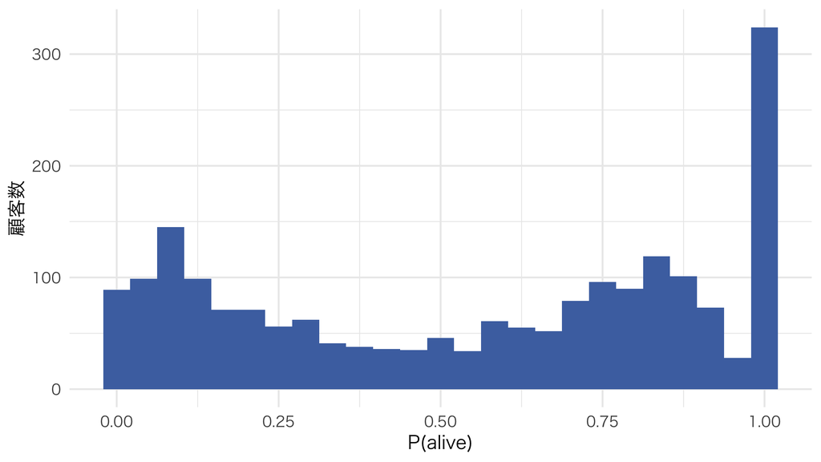

## 同じ沈黙でも履歴で意味が変わる

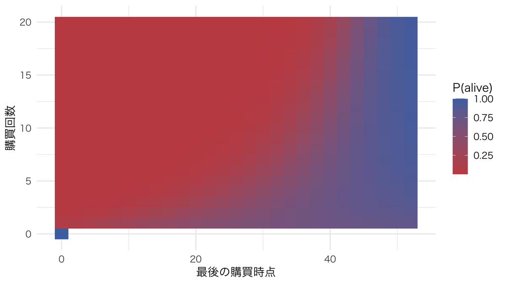

活動状態を観測したわけではなく、仮定のもとで計算した確率である。

## 個人の条件付き分布から予測する

活動しているという条件のもとでは

$$\lambda_i\mid D_i,\mathrm{alive}\sim\mathrm{Gamma}(r+x_i,\alpha+T_i),$$
$$p_i\mid D_i,\mathrm{alive}\sim\mathrm{Beta}(a,b+x_i).$$

まずP(alive)で現在の活動状態を引く。活動中なら上の分布を使い、待ち時間→購買→離脱判定を繰り返す。

## holdoutで確かめる

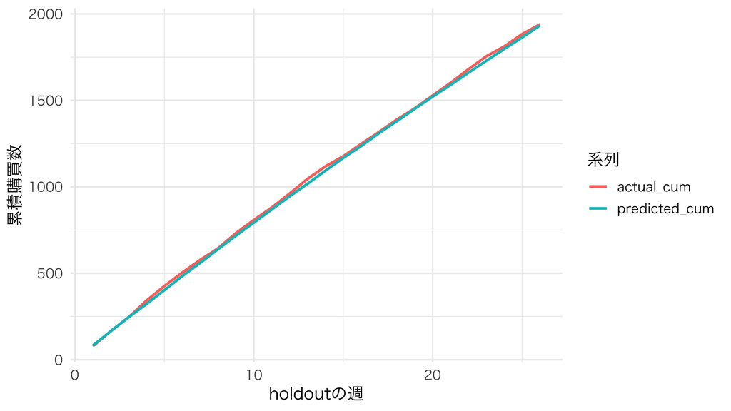

将来を予測する時点までの履歴だけで推定する。

## 個人を順位付けできるだけでは十分でない

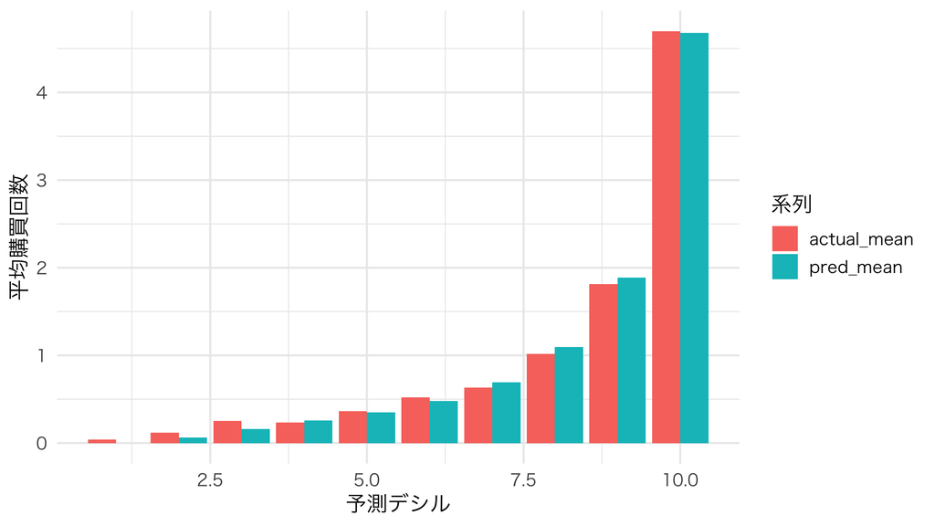

各グループの予測水準と実績水準も比較する。

## 将来購買を利益に変える

$$\mathrm{CLV}_i(H)=\sum_{w=1}^H\frac{m\,E[N_{iw}\mid D_i]}{(1+d)^w}.$$

- $m$：1購買のマージン、$d$：週の割引率。
- 本例では $H=104$ 週。無限の将来を足した値ではない。
- 年率10%なら週の割引率は $(1.1)^{1/52}-1$。

## CLVが高い顧客にクーポンを配るべきか

CLVは、現在の環境が続く場合の将来利益の予測。

施策の配分に必要なのは

$$E[\mathrm{CLV}_i(施策あり)-\mathrm{CLV}_i(施策なし)]-施策費用.$$

第10回と同じく、価値の水準と施策による増分を区別する。

## 実証研究との接点

- Fader et al. (2005)：CDNOWの2,357人、39週間で推定し後半39週間で予測。
- Abe (2009)：階層ベイズで個人パラメータの分布を得る。百貨店400人、52週間など。
- Donkers et al. (2007)：保険の4年間のCLV予測。複雑化が精度改善につながるとは限らない。

出典リンクと限定は講義ノート参照。

## まとめと宿題

- 購買頻度と観測されない離脱をモデル化した。
- 個人の履歴で分布を更新し、将来購買を予測した。
- holdoutで予測を確かめ、有限期間のCLVを計算した。
- CLVの水準だけでは施策の効果は分からない。

Playground 11 / 課題11

## この先：消費者自身も将来を考える

第12回はゲスト講義。

第13回からは、今日の行動が将来の状態を変える動学的選択へ。 今回のモデルは分析者が将来を予測した。 次は、消費者も将来を考えて今日の行動を選ぶ。